# Naive Bayes: Predicting Delayed Flights

Murali Shanker

10/23/2019

## Problem Statement

Predicting flight delays can be useful to a variety of organizations. Here, we look at five predictors. The outcome of interest is whether or not the flight is delayed (delayed here means arrived more than 15 minutes late). Our data consist of all flights from the Washington, DC area into the New York City area during January 2004. A record is a particular flight. The percentage of delayed flights among these 2201 flights is 19.5%. The data were obtained from the Bureau of Transportation Statistics (available on the web at www.transtats.bts.gov). The goal is to accurately predict whether or not a new flight (not in this dataset), will be delayed. The outcome variable is whether the flight was delayed, and thus it has two classes (1 = delayed and 0 = on time).

## Data Preparation

Load required libraries, and read data

```r
require(e1071)
require(caret) # use this to create datasets
delay <- read.csv("./FlightDelays.csv")
str(delay)
```

```
## 'data.frame':    2201 obs. of  13 variables:
##  $ CRS_DEP_TIME : int  1455 1640 1245 1715 1039 840 1240 1645 1715 2120 ...
##  $ CARRIER      : Factor w/ 8 levels "CO","DH","DL",..: 5 2 2 2 2 2 2 2 2 2 ...
##  $ DEP_TIME     : int  1455 1640 1245 1709 1035 839 1243 1644 1710 2129 ...
##  $ DEST         : Factor w/ 3 levels "EWR","JFK","LGA": 2 2 3 3 3 2 2 2 2 2 ...
##  $ DISTANCE     : int  184 213 229 229 229 228 228 228 228 228 ...
##  $ FL_DATE      : Factor w/ 31 levels "01/01/2004","01/02/2004",..: 1 1 1 1 1 1 1 1 1 1 ...
##  $ FL_NUM       : int  5935 6155 7208 7215 7792 7800 7806 7810 7812 7814 ...
##  $ ORIGIN       : Factor w/ 3 levels "BWI","DCA","IAD": 1 2 3 3 3 3 3 3 3 3 ...
##  $ Weather      : int  0 0 0 0 0 0 0 0 0 0 ...
##  $ DAY_WEEK     : int  4 4 4 4 4 4 4 4 4 4 ...
##  $ DAY_OF_MONTH : int  1 1 1 1 1 1 1 1 1 1 ...
##  $ TAIL_NUM     : Factor w/ 549 levels "N10323","N10575",..: 526 263 382 350 385 374 241 227 246 372 ...
##  $ Flight.Status: Factor w/ 2 levels "delayed","ontime": 2 2 2 2 2 2 2 2 2 2 ...
```

```r
head(delay)
```

```
##   CRS_DEP_TIME CARRIER DEP_TIME DEST DISTANCE    FL_DATE FL_NUM ORIGIN
## 1         1455      OH     1455  JFK      184 01/01/2004   5935    BWI
## 2         1640      DH     1640  JFK      213 01/01/2004   6155    DCA
## 3         1245      DH     1245  LGA      229 01/01/2004   7208    IAD
## 4         1715      DH     1709  LGA      229 01/01/2004   7215    IAD
## 5         1039      DH     1035  LGA      229 01/01/2004   7792    IAD
## 6          840      DH      839  JFK      228 01/01/2004   7800    IAD
##   Weather DAY_WEEK DAY_OF_MONTH TAIL_NUM Flight.Status
## 1       0        4            1   N940CA        ontime
## 2       0        4            1   N405FJ        ontime
## 3       0        4            1   N695BR        ontime
## 4       0        4            1   N662BR        ontime
## 5       0        4            1   N698BR        ontime
## 6       0        4            1   N687BR        ontime
```

We need to convert DAY_WEEK and DAY_OF_MONTH into factors. We also need to categorize CRS_DEP_TIME. There are several ways of doing the last. Here, we will group time into buckets of one hour.

```r
delay$DAY_WEEK <- factor(delay$DAY_WEEK)
delay$DAY_OF_MONTH <- factor(delay$DAY_OF_MONTH)

# Now put departure time into one-hour buckets

delay$CRS_DEP_TIME <- factor(round(delay$CRS_DEP_TIME/100))
str(delay)
```

```
## 'data.frame':    2201 obs. of  13 variables:
##  $ CRS_DEP_TIME : Factor w/ 16 levels "6","7","8","9",..: 10 11 7 12 5 3 7 11 12 16 ...
##  $ CARRIER      : Factor w/ 8 levels "CO","DH","DL",..: 5 2 2 2 2 2 2 2 2 2 ...
##  $ DEP_TIME     : int  1455 1640 1245 1709 1035 839 1243 1644 1710 2129 ...
##  $ DEST         : Factor w/ 3 levels "EWR","JFK","LGA": 2 2 3 3 3 2 2 2 2 2 ...
##  $ DISTANCE     : int  184 213 229 229 229 228 228 228 228 228 ...
##  $ FL_DATE      : Factor w/ 31 levels "01/01/2004","01/02/2004",..: 1 1 1 1 1 1 1 1 1 1 ...
##  $ FL_NUM       : int  5935 6155 7208 7215 7792 7800 7806 7810 7812 7814 ...
##  $ ORIGIN       : Factor w/ 3 levels "BWI","DCA","IAD": 1 2 3 3 3 3 3 3 3 3 ...
##  $ Weather      : int  0 0 0 0 0 0 0 0 0 0 ...
##  $ DAY_WEEK     : Factor w/ 7 levels "1","2","3","4",..: 4 4 4 4 4 4 4 4 4 4 ...
##  $ DAY_OF_MONTH : Factor w/ 31 levels "1","2","3","4",..: 1 1 1 1 1 1 1 1 1 1 ...
##  $ TAIL_NUM     : Factor w/ 549 levels "N10323","N10575",..: 526 263 382 350 385 374 241 227 246 372 ...
##  $ Flight.Status: Factor w/ 2 levels "delayed","ontime": 2 2 2 2 2 2 2 2 2 2 ...
```

```r
head(delay)
```

```
##   CRS_DEP_TIME CARRIER DEP_TIME DEST DISTANCE    FL_DATE FL_NUM ORIGIN
## 1           15      OH     1455  JFK      184 01/01/2004   5935    BWI
## 2           16      DH     1640  JFK      213 01/01/2004   6155    DCA
## 3           12      DH     1245  LGA      229 01/01/2004   7208    IAD
## 4           17      DH     1709  LGA      229 01/01/2004   7215    IAD
## 5           10      DH     1035  LGA      229 01/01/2004   7792    IAD
## 6            8      DH      839  JFK      228 01/01/2004   7800    IAD
##   Weather DAY_WEEK DAY_OF_MONTH TAIL_NUM Flight.Status
## 1       0        4            1   N940CA        ontime
## 2       0        4            1   N405FJ        ontime
## 3       0        4            1   N695BR        ontime
## 4       0        4            1   N662BR        ontime
## 5       0        4            1   N698BR        ontime
## 6       0        4            1   N687BR        ontime
```

## Questions

1. Divide the data into 60% training and 40% validation

```r
# First select the required variables
selected.var <- c(1, 2, 4, 8, 10, 13)
set.seed(15)
delay.tr.in = createDataPartition(delay$Flight.Status,p=0.6, list=FALSE) # 60% reserved for Training
delay.tr = delay[delay.tr.in,selected.var]
delay.va <- delay[-delay.tr.in, selected.var] # Validation  data is rest
summary(delay.tr)
```

```
##   CRS_DEP_TIME    CARRIER     DEST     ORIGIN    DAY_WEEK Flight.Status
##  15     :162   DH     :346   EWR:405   BWI: 94   1:192    delayed: 257
##  17     :155   RU     :247   JFK:229   DCA:799   2:180    ontime :1064
##  8      :106   US     :233   LGA:687   IAD:428   3:203
##  16     :103   DL     :232                       4:210
##  12     : 98   MQ     :175                       5:229
##  7      : 84   CO     : 52                       6:150
##  (Other):613   (Other): 36                       7:157
```

```r
summary(delay.va)
```

```
##   CRS_DEP_TIME    CARRIER     DEST     ORIGIN    DAY_WEEK Flight.Status
##  15     :130   DH     :205   EWR:260   BWI: 51   1:116    delayed:171
##  17     : 86   US     :171   JFK:157   DCA:571   2:127    ontime :709
##  16     : 75   RU     :161   LGA:463   IAD:258   3:117
##  13     : 59   DL     :156                       4:162
##  21     : 59   MQ     :120                       5:162
##  8      : 58   CO     : 42                       6:100
##  (Other):413   (Other): 25                       7: 96
```

2. Run the Naive Bayes model to predict whether the flight is delayed or not.

```r
delay.nb <- naiveBayes(Flight.Status ~ ., data = delay.tr)
delay.nb
```

```
##
## Naive Bayes Classifier for Discrete Predictors
##
## Call:
## naiveBayes.default(x = X, y = Y, laplace = laplace)
##
## A-priori probabilities:
## Y
##   delayed    ontime
## 0.1945496 0.8054504
##
## Conditional probabilities:
##          CRS_DEP_TIME
## Y                   6           7           8           9          10
##   delayed 0.046692607 0.070038911 0.077821012 0.019455253 0.038910506
##   ontime  0.061090226 0.062030075 0.080827068 0.057330827 0.047932331
##          CRS_DEP_TIME
## Y                  11          12          13          14          15
##   delayed 0.011673152 0.054474708 0.035019455 0.066147860 0.167315175
##   ontime  0.034774436 0.078947368 0.060150376 0.058270677 0.111842105
##          CRS_DEP_TIME
## Y                  16          17          18          19          20
##   delayed 0.077821012 0.147859922 0.023346304 0.077821012 0.007782101
##   ontime  0.078007519 0.109962406 0.037593985 0.044172932 0.022556391
##          CRS_DEP_TIME
## Y                  21
##   delayed 0.077821012
##   ontime  0.054511278
##
##          CARRIER
## Y                  CO          DH          DL          MQ          OH
##   delayed 0.035019455 0.346303502 0.101167315 0.182879377 0.007782101
##   ontime  0.040413534 0.241541353 0.193609023 0.120300752 0.012218045
##          CARRIER
## Y                  RU          UA          US
##   delayed 0.233463035 0.011673152 0.081712062
##   ontime  0.175751880 0.016917293 0.199248120
##
##          DEST
## Y               EWR       JFK       LGA
##   delayed 0.3852140 0.1867704 0.4280156
##   ontime  0.2875940 0.1701128 0.5422932
##
##          ORIGIN
## Y                BWI        DCA        IAD
##   delayed 0.10505837 0.48249027 0.41245136
##   ontime  0.06296992 0.63439850 0.30263158
##
##          DAY_WEEK
## Y                  1          2          3          4          5
##   delayed 0.19455253 0.14396887 0.12840467 0.13618677 0.17509728
##   ontime  0.13345865 0.13439850 0.15977444 0.16447368 0.17293233
##          DAY_WEEK
## Y                  6          7
##   delayed 0.05447471 0.16731518
##   ontime  0.12781955 0.10714286
```

3. Output both a counts table and a proportion table outlining how many and what proportion of flights were delayed and on-time at each of the three airports.

We will use prop.table() to output the proportions from counts

```r
table(delay.tr$Flight.Status,delay.tr$DEST)
```

```
##
##           EWR JFK LGA
##   delayed  99  48 110
##   ontime  306 181 577
```

```r
prop.table(table(delay.tr$Flight.Status,delay.tr$DEST),margin = 1)
```

```
##
##                 EWR       JFK       LGA
##   delayed 0.3852140 0.1867704 0.4280156
##   ontime  0.2875940 0.1701128 0.5422932
```

```r
 # This will sum row probabilities to 1
```

4. Output the confusion matrix and ROC for the validation data

Let us output the confusion matrices for the training and validation sets

```r
# Training set
pred.class <- predict(delay.nb, newdata = delay.tr)
confusionMatrix(pred.class, delay.tr$Flight.Status)
```

```
## Confusion Matrix and Statistics
##
##           Reference
## Prediction delayed ontime
##    delayed      33     38
##    ontime      224   1026
##
##                Accuracy : 0.8017
##                  95% CI : (0.7791, 0.8229)
##     No Information Rate : 0.8055
##     P-Value [Acc > NIR] : 0.6511
##
##                   Kappa : 0.1278
##
##  Mcnemar's Test P-Value : <2e-16
##
##             Sensitivity : 0.12840
##             Specificity : 0.96429
##          Pos Pred Value : 0.46479
##          Neg Pred Value : 0.82080
##              Prevalence : 0.19455
##          Detection Rate : 0.02498
##    Detection Prevalence : 0.05375
##       Balanced Accuracy : 0.54635
##
##        'Positive' Class : delayed
##
```

```r
# validation
pred.prob <- predict(delay.nb, newdata=delay.va, type="raw") # probabilities
pred.class <- predict(delay.nb, newdata = delay.va) # class membership
confusionMatrix(pred.class, delay.va$Flight.Status)
```

```
## Confusion Matrix and Statistics
##
##           Reference
## Prediction delayed ontime
##    delayed      17     12
##    ontime      154    697
##
##                Accuracy : 0.8114
##                  95% CI : (0.7839, 0.8367)
##     No Information Rate : 0.8057
##     P-Value [Acc > NIR] : 0.3535
##
##                   Kappa : 0.1204
##
##  Mcnemar's Test P-Value : <2e-16
##
##             Sensitivity : 0.09942
##             Specificity : 0.98307
##          Pos Pred Value : 0.58621
##          Neg Pred Value : 0.81904
##              Prevalence : 0.19432
##          Detection Rate : 0.01932
##    Detection Prevalence : 0.03295
##       Balanced Accuracy : 0.54124
##
##        'Positive' Class : delayed
##
```

We will now output the ROC

```r
# install.packages("pROC") # install if necessary
require(pROC)
# Note the delayed probabilities are in column 1

roc(delay.va$Flight.Status,pred.prob[,1])
```

```
##
## Call:
## roc.default(response = delay.va$Flight.Status, predictor = pred.prob[,     1])
##
## Data: pred.prob[, 1] in 171 controls (delay.va$Flight.Status delayed) > 709 cases (delay.va$Flight.Status ontime).
## Area under the curve: 0.6561
```

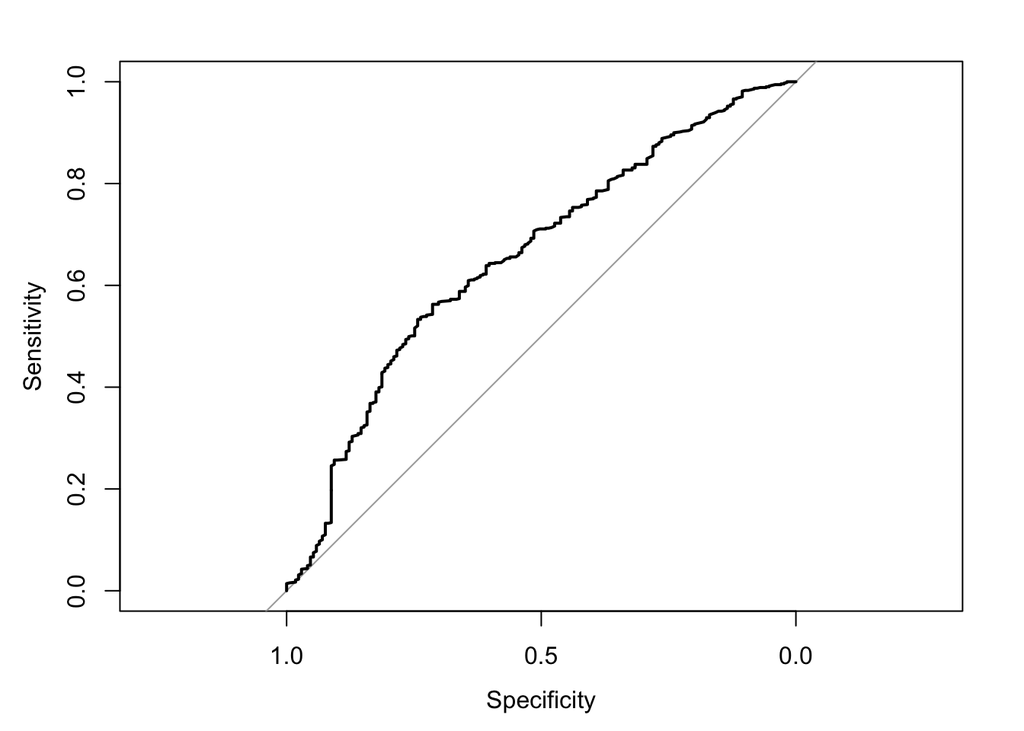

```r
plot.roc(delay.va$Flight.Status,pred.prob[,1])
```